# Survey Analysis in R

Aaron R. Williams (IBP)

July 15, 2020

# 1 Why Surveys?

A *population* (or universe) is the collection of all elements or units that we wish to consider in an investigation. A *parameter* is any characteristic of the population. Common parameters are totals, means, median, and proportions.

A key task in social and economic policy research is estimating and studying population parameters. Examples include:

- Median household income in the United States
- Total unemployed, as a percent of the civilian labor force (official unemployment rate)

A *census* is a procedure by which a questionnaire is given to every element or unit in a population. The Decennial Census is an example of a census.

A census can be expensive and challenging. To save time and money, parameters are often estimated by statistics from samples. A *sample* is a (nonempty) subset or portion of a population. A *statistic* is any characteristic of a sample.

In addition to estimating parameters, researchers want to understand any uncertainty of the estimates. Later sections will focus on estimating uncertainty caused by sampling and other sources.

*All italicized definitions come from Wright (unpublished).*

# 2 Federal Surveys

Federal surveys are rich sources of information for social and economic policy research. The U.S. Census Bureau is the largest source of federal surveys including the American Community Survey and the Current Population Survey.

## 2.1 American Community Survey

The American Community Survey is an annual survey of about 3.5 million households administered by the U.S. Census Bureau. It is one of the best sources for information about small geographies. It is common to combine five years of surveys to increase the precision of parameter estimates.

The Census Bureau releases published tables of many population parameters for many geographies and demographic variables. The Census Bureau also releases microdata, which allow for calculating additional parameter estimates with considerably more effort than the published tables.

## 2.2 Current Population Survey

The Current Population Survey is a monthly survey of about 60,000 households administered by the U.S. Census Bureau for the Bureau of Labor Statistics. It is the source of the official U.S. employment rate.

# 3 IPUMS

The [Integrated Public Use Microdata Series (IPUMS)](https://ipums.org/) releases cleaned versions of the ACS and CPS that are easier to use and are cleaned over time for consistency. IPUMS maintains an R packages called `library(ipumsr)` that makes easy loading data from IPUMS. A brief intro to `library(ipumsr)` is available [here](https://cran.r-project.org/web/packages/ipumsr/vignettes/ipums.html).

## 3.1 Exercise 1

**Step 1:** Sign up for [IPUMS USA](https://usa.ipums.org/usa/)

**Step 2:** Install `library(ipumsr)`

# 4 Weights

A *simple random sample* is a random sample of $n$ units from a finite population of size $N$. In this case, an unweighted sample total will be a poor estimate of the population total.

```r
# define a population
population <- c(12, 14, 16, 19, 10,
                20, 22, 10, 10, 12)

# set a seed for reproducibility and sample
set.seed(20200722)

sample <- sample(population, size = 5)

# calculate the sample statistic and population parameter
c(`Sample total` = sum(sample), `Population total` = sum(population))
```

```
##     Sample total Population total
##               71              145
```

Weights improve the accuracy of sample statistics so they better match the population parameter of interest. Accordingly, a weighted total is calculated with weights equal to the inverse of the probability of selection.

```r
# weight the observation by the inverse of 1/2
c(`Weighted sample total` = sum(sample * 2))
```

```
## Weighted sample total
##                   142
```

Different sampling schemes and adjustments for factors like non-response often result in weights that are far more complicated than above. Oftentimes, weights are reported as variables in microdata.

```r
data <- tribble(
  ~x, ~weight,
  12, 100,
  14, 200,
  16, 150,
  19, 500,
  10, 100
)

# calculate the weighted mean
weighted.mean(x = data$x, w = data$weight)
```

```
## [1] 16.09524
```

# 5 American Community Survey (ACS)

## 5.1 Exercise 2a

**Step 1:** [Sign up for a Census API key](https://api.census.gov/data/key_signup.html).

The Census Bureau publishes ACS tables online with this [data tool](https://data.census.gov/cedsci/table?q=dp&tid=ACSDP1Y2018.DP05). However, `library(tidycensus)` can be used to access many of the same tables directly in `R` in an easier and more reproducible way. [Here](https://walker-data.com/tidycensus/articles/basic-usage.html) is a brief introduction to `library(tidycensus)`.

These tables already account for the sample weights. This is a huge help! However, we’ll eventually want to calculate a statistic that isn’t published in a table and we will need to use the microdata.

The following code pulls ACS 1-year estimates of median household income for all fifty states, DC, and Puerto Rico in 2018:

```r
library(tidycensus)

get_acs(geography = "state",
        variables = c(medincome = "B19013_001"),
        survey = "acs1",
        year = 2018)
```

```
## # A tibble: 52 x 5
##    GEOID NAME                 variable  estimate   moe
##    <chr> <chr>                <chr>        <dbl> <dbl>
##  1 01    Alabama              medincome    49861   783
##  2 02    Alaska               medincome    74346  2288
##  3 04    Arizona              medincome    59246   732
##  4 05    Arkansas             medincome    47062   713
##  5 06    California           medincome    75277   317
##  6 08    Colorado             medincome    71953   655
##  7 09    Connecticut          medincome    76348   921
##  8 10    Delaware             medincome    64805  1570
##  9 11    District of Columbia medincome    85203  3414
## 10 12    Florida              medincome    55462   384
## # … with 42 more rows
```

Note how the returned table includes an estimate and a margin of error. **Across repeated samples of the population, the true median household income is between the estimate minus the moe and the estimate plus the moe 90 percent of the time**. This range is a 90% confidence interval.

## 5.2 Exercise 2b

**Step 2:** Install and load `library(tidycensus)`. Add the key with `census_api_key("YOUR API KEY GOES HERE")`.

**Step 3:** Using the code above, pull the state-level median household income for 2016, 2017, and 2018.

**Step 4:** Add a variable called `year` to each data frame with the year of the data.

**Step 5:** Combine the three data frames with `bind_rows()`.

## 5.3 Exercise 3

**Step 2:** Create the following plot. Note, use `theme_minimal()`.

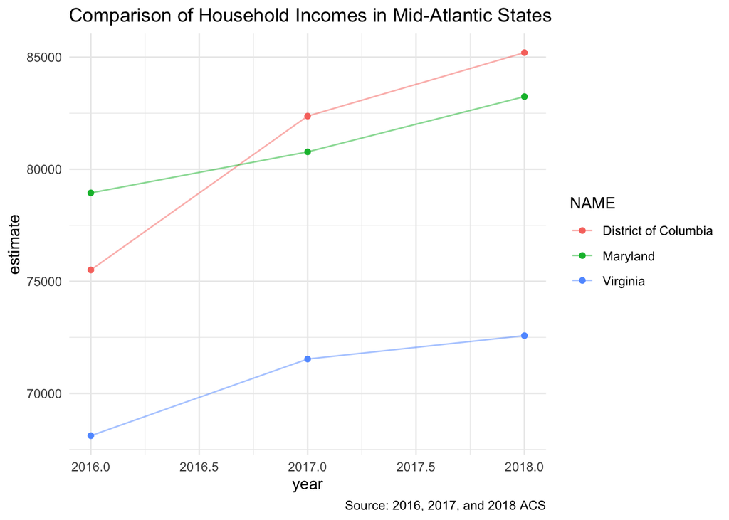

# 6 `library(srvyr)`

`library(survey)` is a powerful package for survey analysis by Thomas Lumley’s book, the author of [Complex Surveys: A Guide to Analysis Using R](https://www.wiley.com/en-us/Complex+Surveys%3A+A+Guide+to+Analysis+Using+R-p-9780470284308). `library(srvyr)` is an extension package that works better with the tidyverse.

There are two main steps.

1. Identify the survey design and create a `survey` object with `as_survey_design()`.
2. Calculate summary statistics and estimates of uncertainty like confidence intervals with `summarize()` and `survey_*()` functions.

Important arguments in `as_survey_design()` are `weights =` for picking a weight, `fpc =` for finite population correction, and `strat =` for identifying strata.

`survey_*()` functions include:

- `survey_count()`
- `survey_mean()`
- `survey_median()`
- `survey_quantile()`
- `survey_ratio()`
- `survey_sd()`
- `survey_tally()`
- `survey_total()`
- `survey_var()`

```r
library(survey)
library(srvyr)

# add api data to the global environment
data(api)

# create a survey object
apisrs <- apisrs %>%
  as_survey_design(fpc = fpc, weight = pw)

# calculate the weighted mean
apisrs %>%
  summarize(mean_weighted = survey_mean(api00, vartype = "ci"))
```

```
## # A tibble: 1 x 3
##   mean_weighted mean_weighted_low mean_weighted_upp
##           <dbl>             <dbl>             <dbl>
## 1          657.              638.              675.
```

## 6.1 Exercise 4

**Step 1:** Install `library(survey)` and `library(srvyr)`

**Step 2:** Create a `survey` object for `apistrat`. Identify the strata ID and add it using the `strat =` argument.

**Step 3:** Calculate the mean, median, and 75th percentile of `api00` in one `summarize()` call. Include confidence intervals.

**Step 4:** Group by school type (`stype`) and calculate the mean of `api00`.

# 7 CPS

We’re now going to estimate the proportion of the population ages 40 to 61 who have a disability disability that limits or prevents work (“Disability limits or prevents work”).

## 7.1 Exercise 5

**Step 1:** Put `cps_00004.csv.gz` and `cps_0004.xml` in the appropriate directory.

**Step 2:** Create an object called `cps_ddi` by using `read_ipums_ddid()` and the `"cps_00004.xml"`.

**Step 3:** Create an object called `cps` with `read_ipums_micro()`.

**Step 4:** Create a labeled factor with the following code `mutate(disabwrk = as_factor(lbl_clean(DISABWRK)))` Also, convert `AGE` to a numeric variable.

**Step 5:** Create a `survey` object with `as_survey_design()`

**Note:** The confidence intervals created by this will be underestimates. We need replicate weights for the most accurate confidence intervals. For now, set `vartype = NULL`.

**Step 6:** Create a dummy variable called `disabwrk_dum` if `DISABWRK == "Disability limits or prevents work"`.

**Step 7:** Calculate the weighted total and weighted mean of `disabwrk_dum`.

# 8 Solutions

## 8.1 Exercise 2

```r
library(tidycensus)

acs2016 <- get_acs(geography = "state",
                   variables = c(medincome = "B19013_001"),
                   survey = "acs1",
                   year = 2016) %>%
  mutate(year = 2016)

acs2017 <- get_acs(geography = "state",
        variables = c(medincome = "B19013_001"),
        survey = "acs1",
        year = 2017) %>%
  mutate(year = 2017)

acs2018 <- get_acs(geography = "state",
                   variables = c(medincome = "B19013_001"),
                   survey = "acs1",
                   year = 2018) %>%
  mutate(year = 2018)

acs <- bind_rows(acs2016, acs2017, acs2018)

acs %>%
  filter(year == 2016) %>%
  slice_min(moe, n = 10)
```

## 8.2 Exercise 3

```r
acs <- acs %>%
  mutate(state = ifelse(NAME == "Virginia", "Virginia", "Other state"))

acs %>%
  filter(NAME %in% c("District of Columbia", "Maryland", "Virginia")) %>%
  ggplot(aes(year, estimate, color = NAME)) +
  geom_point() +
  geom_line(alpha = 0.5) +
  labs(title = "Comparison of Household Incomes in Mid-Atlantic States",
       caption = "Source: 2016, 2017, and 2018 ACS") +
  theme_minimal()
```

## 8.3 Exercise 4

```r
apistrat <- apistrat %>%
  as_survey_design(strata = stype, fpc = fpc, weight = pw)

apistrat %>%
  group_by(stype) %>%
  summarize(api00_mean = survey_mean(api00, vartype = "ci"))
```

## 8.4 Exercise 5

```r
library(tidyverse)
library(srvyr)
library(ipumsr)

# create the DDI
cps_ddi <- read_ipums_ddi(here::here("lessons", "08_survey-analysis", "cps_00004.xml"))

# read the data
cps <- read_ipums_micro(cps_ddi)


# convert age into a numeric variable
cps <- cps %>%
  mutate(DISABWRK = as_factor(lbl_clean(DISABWRK))) %>%
  mutate(AGE = as.numeric(AGE))

# create a survey object
cps <- cps %>%
  as_survey_design(weight = ASECWT)

# limit the sample to ages of interest and create a dummy variable
cps <- cps %>%
  filter(AGE >= 40, AGE <= 61) %>%
  mutate(disabwrk_dum = DISABWRK == "Disability limits or prevents work")

# calculate the sample statistics to estimate the population proportions
cps %>%
  summarize(
    `Count with a Self-Reported Work Limitation` = survey_total(disabwrk_dum, vartype = NULL),
    `Proportion with a Self-Reported Work Limitation` = survey_mean(disabwrk_dum, vartype = NULL))
```